# Introduction to Independent Guides

This document is intended for learners who skipped Course 1 from this series and already have some familiarity with R and RStudio, including either having downloaded and installed these programs on their own computer or having access to cloud-based versions of these programs via https://posit.cloud/. Learners who have completed Course 1 from this series should already be familiar with the purpose of independent guides for this course and do not need to read the rest of this document. We recommend that those who are brand new to R and RStudio work through Course 1 in this series before proceeding.

The pattern of learning for this course will generally proceed through the following steps:

1. **Learning** about ideas through lecture-style videos.
2. **Implementing** those ideas together in a guided practice video, where the instructor demonstrates the use of specific functions in R, and learners can repeat the steps that the instructor demonstrates.
3. Repeating Steps 1 and 2 for all topics in a lesson.
4. **Reinforcing** on your own by following along a series of written steps called ‘independent guides’, which cover all topics in a lesson.
5. **Practicing** your understanding of these ideas through non-graded quizzes.

In this document, we provide some context for the independent guides in Step 4, namely: what they will cover, when to work them, and how to use them.

#### Independent guides will re-visit the content covered in the guided practices

For some, the most efficient way to learn to code is by watching and repeating, whereas for others it is by reading and copying. Step 2 (implementing via guided practice) relies upon the former, whereas Step 4 (reinforcing via independent guides) uses the latter. Thus, a defining feature of the independent guides is that what’s covered in Step 2 will be covered again in Step 4. If you don’t understand something the instructor *says* (or even if you do understand), you will have a second chance to engage with the same content by reading what the instructor *writes*.

#### Independent guides sometimes provide additional nuance or explanation

Written communication provides opportunities for nuance and multiple simultaneous lines of thought that can be more challenging in oral communication. In addition, topics within one lesson often share important connections. Thus, the independent guides in Step 4, being written summations of many videos/topics in a lesson, provide additional background on a key concept or on the relationship between multiple topics. *For this reason, we recommend you read the independent guides for all topics.*

#### Work through the independent guides after watching the guided practices

As stated above, the independent guides are intended to complement and enhance the guided practice videos from a single lesson. After working through all videos in a single lesson (Steps 1 and 2), we recommend you also open the independent guide for that lesson and then test your own understanding by taking the practice quiz (Steps 4 and 5). In other words, working through an entire lesson (Steps 1–5) is the most natural ‘learning unit’ in this course. It is not absolutely necessary that you complete an entire lesson in one sitting, but bear in mind that these steps are intended to be reinforcing, and so taking breaks between lessons is preferred to taking breaks within a lesson.

#### Run R code from the independent guides in your own session

The language in the independent guides is informal and instructional. Like the guided practice videos, these guides teach by doing, so it is assumed you will have an R session open and that you’ll be copying and pasting (or re-typing) code from the independent guide into your R session as you read through the guide. You will be instructed to copy and paste lines of code from the document into your own R session, examples of which are given in the next section.

Because the independent guides will repeat everything done in the guided practice session, you will ultimately need to decide whether you will only actually copy and run code while watching the guided practice, while reading the independent guides, or both. Whatever you decide, it is recommended that you still both watch the guided practice videos and read through independent guides.

### Installing R packages for this course and getting familiar with R

You will need to install two R packages for this course: `tidyverse` and `healthds`. This section walks you through how to do so and covers the basics of interfacing with R and RStudio.

#### How to install `tidyverse`

To install `tidyverse`, you need to run the following line of code in your console:

```r
install.packages("tidyverse")
```

You can copy this R code by pressing the small symbol in the top-right of each box. The default location of the console in RStudio is in the lower-left panel of your screen. Find the console, put your cursor there, paste this code, and then press Enter/Return to run it.

Installation of `tidyverse` may take a few minutes, since your computer will need to find the package on the internet, download it, and install it (along with other packages that `tidyverse` requires, called dependencies). A successful installation should print a message like this to the console:

```
##
##  /var/folders/8k/3_ytl3154bg402cwzkpy7z0m0000gn/T//Rtmp7GLlr9/downloaded_packages
```

Upon successful installation, the `tidyverse` package is now installed on your computer. You only need to *install* an R package onto your computer once, even if you close RStudio or turn off your computer. However, before you can use the additional functions in an R package, you need to take the additional step of *loading* any R package, and you need to load an R package anytime you close and re-open RStudio. Having installed `tidyverse` using the code above, the code below will load `tidyverse` into your R session and make its functions available for use:

```r
library(tidyverse)
```

Copy this code and paste it into your console following the same steps as before. If successful, you should see some messages in the R console similar to the image below:

[figure not shown]

**Image description: Successfully loaded tidyverse**

One of the features that makes R so powerful is the ability for a user to write out and save a set of instructions, as opposed to directly pasting them in the console. This makes recreating and sharing analyses much easier. To do so, we recommend you put your code into an R script and then run the commands from that script.

R scripts are files that you create in RStudio. You can open a new script by pressing ‘Cmd+Shift+N’ on your Mac or ‘Ctrl+Shift+N’ on your Windows computer. Or, from the dropdown menu, go to ‘File > New File > R Script’:

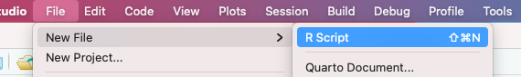

**Image description: creating a new script using dropdown menus**

A new window should have appeared in your RStudio console. It will be blank. R scripts are like recipes: they contain a list of step-by-step instructions for conducting your analysis. And like recipes, scripts are not useful unless you actually implement the instructions, meaning that you can type code in an R script, but unless you run that code in the console, it won’t do anything. To run code from a script into the console, put your cursor on the line of code you want to run and press Ctrl+Enter (Windows) or Cmd+Enter (Mac).

You will not need to re-install `tidyverse` if you close RStudio, but you will need to re-load it, i.e. using the `library` command. Therefore, you should put `library(tidyverse)` at the top of any script inside which you intend to use functions from `tidyverse`.

#### How to install `healthds`

Installing the `healthds` package is slightly more complicated because it has been developed specifically for learners in this course, and it is not located in the usual repositories that the `install.packages` function would look in. To install `healthds`, we first need to install and load a package called `remotes`:

```r
install.packages("remotes")
library(remotes)
```

Next, we will use a function from the `remotes` package called `install_git`. This function acts similarly to `install.packages` but allows us to install packages that are hosted on GitHub, a repository where any user can develop and publicly share software. To install `healthds`, run the following line of code (it is easiest to copy-paste this directly into your R console):

```r
install_git("https://github.com/umich-biostatistics/healthds", upgrade = "never")
```

If you run the above line of code without first having installed and loaded `remotes`, you will get an error message that the function `install_git` is not found. Just as with `tidyverse`, you must load `healthds` using the `library` command. Therefore, type `library(healthds)` in your script, just below `library(tidyverse)`.

To summarize, for any independent guide that you do in this course, you should put the following commands at the top of your script to ensure that you have access to the functions that they contain:

```r
library(tidyverse)
library(healthds)
```

And execute these commands by putting your cursor on each line and pressing Ctrl+Enter (Windows) or Cmd+Enter (Mac).

[figure not shown]

**Image description: Run a line of code from an R script**